# Práctica 1 - Herramientas Exploratorias para una Variable

Jordi Gisbert

# 1. Hoja de datos

Cargamos el fichero de datos con read.csv. El fichero tiene espacios en los nombres de columna y en los valores, así que los limpiamos.

```r
datos <- read.csv("CURS8990-Codif.csv", fileEncoding = "latin1", strip.white = TRUE)
datos <- datos[, 1:11]
head(datos)
```

```
##     SEXO EDAD MES ESTATURA PESO  POLITICA DIGITO RESIDENCIA TRANSPORTE TIEMPO
## 1 chicos   20   1      183   76 izquierda      5       piso      a pie     15
## 2 chicos   21   6      185   72    centro      8       otra      coche     10
## 3 chicos   22  10      165   75     pasan      8    familia  t publico     30
## 4 chicos   22   4      174   70     pasan      6 residencia      a pie     15
## 5 chicos   22   7      175   70     pasan      7       piso      a pie     20
## 6 chicos   20  11      175   70   derecha      3    familia  compañero     60
##      PROBLEMA
## 1 desigualdad
## 2  terrorismo
## 3 desigualdad
## 4       droga
## 5 desigualdad
## 6     valores
```

# 2. Análisis exploratorios

## 2.1. Información sobre el conjunto de datos

```r
cat("Numero de variables:", ncol(datos), "\n")
```

```
## Numero de variables: 11
```

```r
cat("Numero de alumnos:", nrow(datos), "\n")
```

```
## Numero de alumnos: 131
```

```r
cat("Casos completos:", sum(complete.cases(datos)), "\n")
```

```
## Casos completos: 131
```

```r
str(datos)
```

```
## 'data.frame':    131 obs. of  11 variables:
##  $ SEXO      : chr  "chicos" "chicos" "chicos" "chicos" ...
##  $ EDAD      : int  20 21 22 22 22 20 22 23 21 21 ...
##  $ MES       : int  1 6 10 4 7 11 7 10 3 6 ...
##  $ ESTATURA  : int  183 185 165 174 175 175 174 159 177 180 ...
##  $ PESO      : int  76 72 75 70 70 70 65 54 72 73 ...
##  $ POLITICA  : chr  "izquierda" "centro" "pasan" "pasan" ...
##  $ DIGITO    : int  5 8 8 6 7 3 7 5 8 5 ...
##  $ RESIDENCIA: chr  "piso" "otra" "familia" "residencia" ...
##  $ TRANSPORTE: chr  "a pie" "coche" "t publico" "a pie" ...
##  $ TIEMPO    : int  15 10 30 15 20 60 5 65 15 15 ...
##  $ PROBLEMA  : chr  "desigualdad" "terrorismo" "desigualdad" "droga" ...
```

## 2.2. Variables cualitativas - RESIDENCIA

### Tabla de frecuencias

```r
frec <- table(datos$RESIDENCIA)
frec_rel <- round(prop.table(frec) * 100, 2)
frec_acum <- cumsum(frec)
frec_rel_acum <- cumsum(frec_rel)

tabla_res <- data.frame(
  Frec_abs = as.numeric(frec),
  Frec_rel = as.numeric(frec_rel),
  Frec_acum = as.numeric(frec_acum),
  Frec_rel_acum = as.numeric(frec_rel_acum)
)
rownames(tabla_res) <- names(frec)
tabla_res
```

```
##            Frec_abs Frec_rel Frec_acum Frec_rel_acum
## familia          68    51.91        68         51.91
## otra             13     9.92        81         61.83
## pension           1     0.76        82         62.59
## piso             37    28.24       119         90.83
## residencia       12     9.16       131         99.99
```

### Diagrama de barras

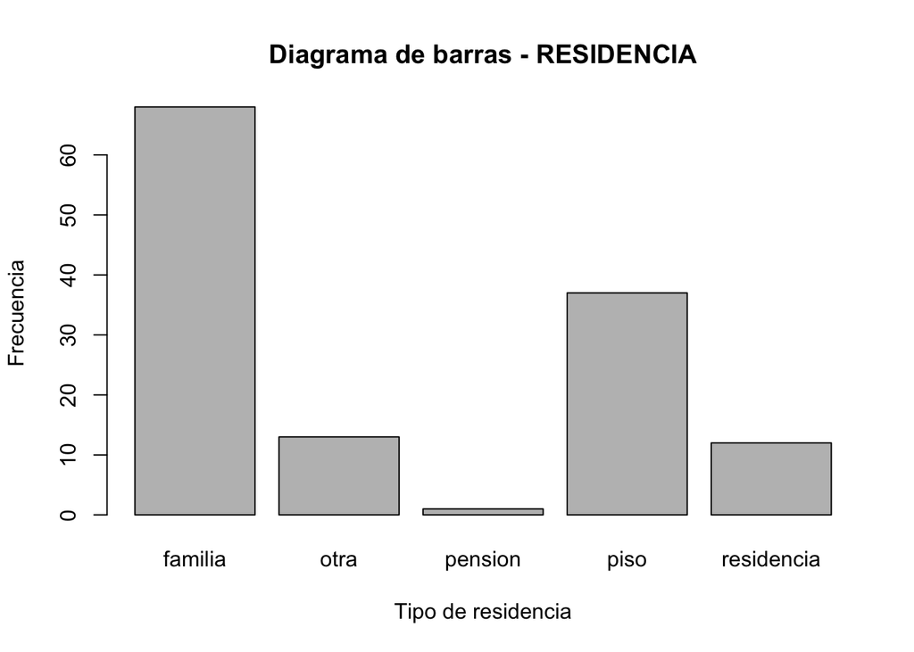

```r
barplot(frec, main = "Diagrama de barras - RESIDENCIA",
        xlab = "Tipo de residencia", ylab = "Frecuencia")
```

### Diagrama de sectores

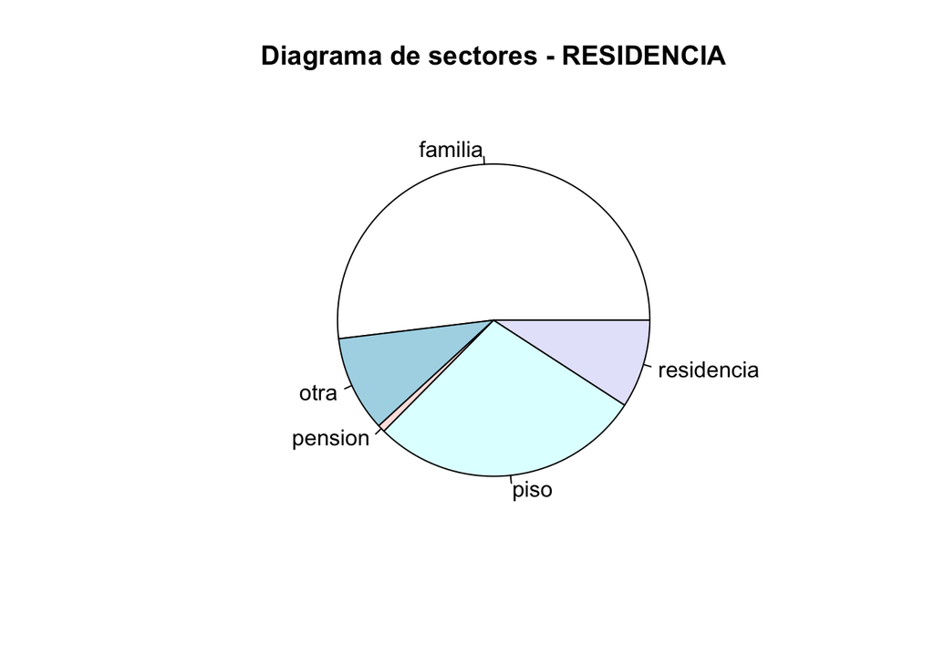

```r
pie(frec, main = "Diagrama de sectores - RESIDENCIA")
```

## 2.3. Variables cuantitativas - PESO

### Tabla de frecuencias

```r
breaks_peso <- seq(40, 95, length.out = 11)
clases <- cut(datos$PESO, breaks = breaks_peso, include.lowest = TRUE, right = FALSE)
frec_peso <- table(clases)
frec_rel_peso <- round(prop.table(frec_peso) * 100, 2)
frec_acum_peso <- cumsum(frec_peso)
frec_rel_acum_peso <- cumsum(frec_rel_peso)

tabla_peso <- data.frame(
  Frec_abs = as.numeric(frec_peso),
  Frec_rel = as.numeric(frec_rel_peso),
  Frec_acum = as.numeric(frec_acum_peso),
  Frec_rel_acum = as.numeric(frec_rel_acum_peso)
)
rownames(tabla_peso) <- names(frec_peso)
tabla_peso
```

```
##           Frec_abs Frec_rel Frec_acum Frec_rel_acum
## [40,45.5)        1     0.76         1          0.76
## [45.5,51)        9     6.87        10          7.63
## [51,56.5)       21    16.03        31         23.66
## [56.5,62)       14    10.69        45         34.35
## [62,67.5)       25    19.08        70         53.43
## [67.5,73)       23    17.56        93         70.99
## [73,78.5)       22    16.79       115         87.78
## [78.5,84)        7     5.34       122         93.12
## [84,89.5)        7     5.34       129         98.46
## [89.5,95]        2     1.53       131         99.99
```

La Clase 3 muestra cuántos alumnos tienen un peso dentro de ese intervalo, qué porcentaje representan y los acumulados hasta esa clase.

### Histograma - todos los alumnos

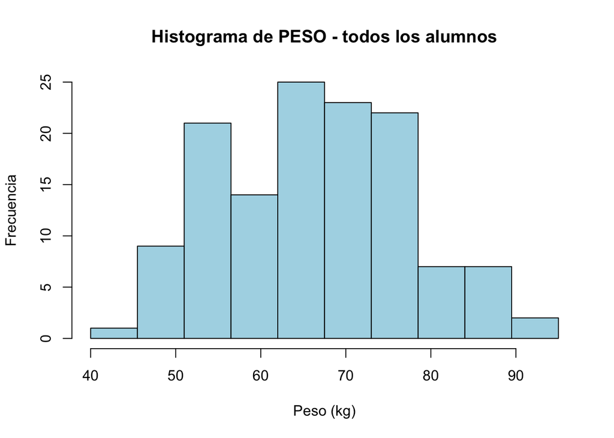

```r
hist(datos$PESO, breaks = breaks_peso, right = FALSE,
     main = "Histograma de PESO - todos los alumnos",
     xlab = "Peso (kg)", ylab = "Frecuencia", col = "lightblue")
```

El histograma muestra que la mayoría de alumnos pesa entre 60 y 75 kg, con una ligera asimetría hacia la derecha.

### Histograma - solo chicos

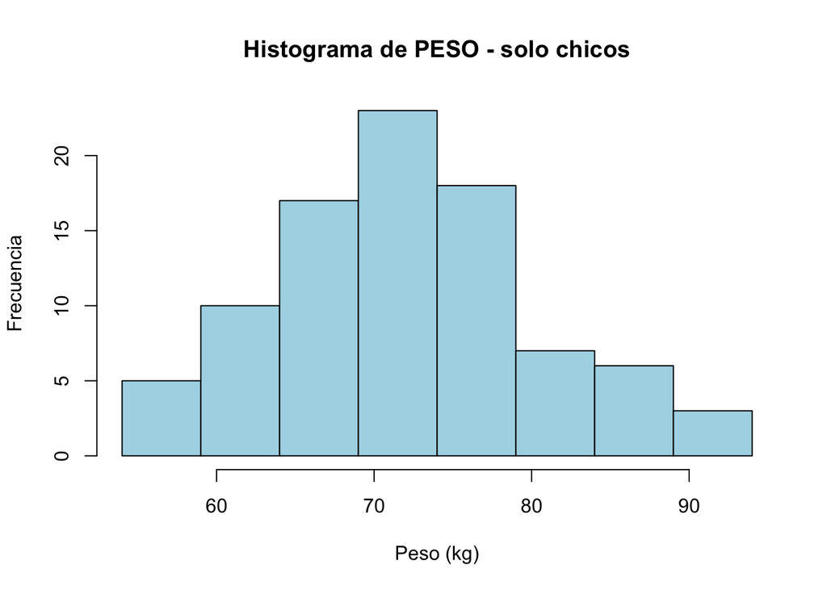

```r
chicos <- datos[datos$SEXO == "chicos", ]
breaks_chicos <- seq(54, 94, length.out = 9)

hist(chicos$PESO, breaks = breaks_chicos, right = FALSE,
     main = "Histograma de PESO - solo chicos",
     xlab = "Peso (kg)", ylab = "Frecuencia", col = "lightblue")
```

Comparado con el de todos los alumnos, el histograma de los chicos se desplaza a la derecha, lo cual tiene sentido.

### Poligono de frecuencias acumuladas - chicos

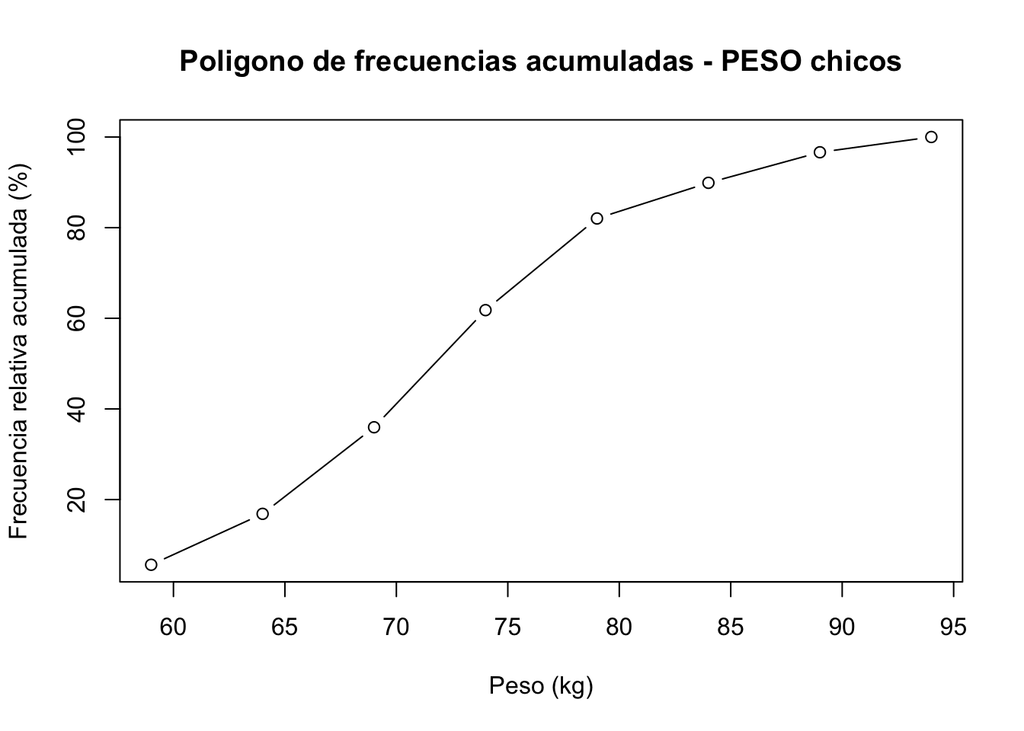

```r
clases_chicos <- cut(chicos$PESO, breaks = breaks_chicos,
                     include.lowest = TRUE, right = FALSE)
frec_ch <- table(clases_chicos)
frec_acum_ch <- cumsum(frec_ch) / sum(frec_ch) * 100
limites_sup <- breaks_chicos[-1]

plot(limites_sup, frec_acum_ch, type = "b",
     main = "Poligono de frecuencias acumuladas - PESO chicos",
     xlab = "Peso (kg)", ylab = "Frecuencia relativa acumulada (%)")
```

### Percentiles - chicos

```r
quantile(chicos$PESO, probs = c(0.10, 0.25, 0.50, 0.75, 0.90), na.rm = TRUE)
```

```
##  10%  25%  50%  75%  90%
## 60.8 66.0 71.0 76.0 81.6
```

Los percentiles son la lectura inversa del poligono acumulado: si el poligono llega al 75% en el peso X, entonces P75 = X.

### Medidas resumen - todos los alumnos

```r
peso <- datos$PESO

cat("Media:", mean(peso, na.rm = TRUE), "\n")
```

```
## Media: 66.21374
```

```r
cat("Mediana:", median(peso, na.rm = TRUE), "\n")
```

```
## Mediana: 66
```

```r
cat("Desv. tipica:", sd(peso, na.rm = TRUE), "\n")
```

```
## Desv. tipica: 10.65689
```

```r
cat("Varianza:", var(peso, na.rm = TRUE), "\n")
```

```
## Varianza: 113.5693
```

```r
cat("Minimo:", min(peso, na.rm = TRUE), "\n")
```

```
## Minimo: 45
```

```r
cat("Maximo:", max(peso, na.rm = TRUE), "\n")
```

```
## Maximo: 90
```

```r
cat("Rango:", diff(range(peso, na.rm = TRUE)), "\n")
```

```
## Rango: 45
```

```r
cat("Q1:", quantile(peso, 0.25, na.rm = TRUE), "\n")
```

```
## Q1: 57
```

```r
cat("Q3:", quantile(peso, 0.75, na.rm = TRUE), "\n")
```

```
## Q3: 74
```

```r
cat("IQR:", IQR(peso, na.rm = TRUE), "\n")
```

```
## IQR: 17
```

```r
cat("Coef. de variacion (%):", round(sd(peso, na.rm = TRUE) / mean(peso, na.rm = TRUE) * 100, 2), "\n")
```

```
## Coef. de variacion (%): 16.09
```

Los parametros robustos (mediana, IQR, cuartiles) no se ven afectados por valores extremos. Los no robustos (media, desviacion tipica) si. Si hubiera outliers claros conviene usar mediana e IQR.

### Diagrama de caja y bigotes

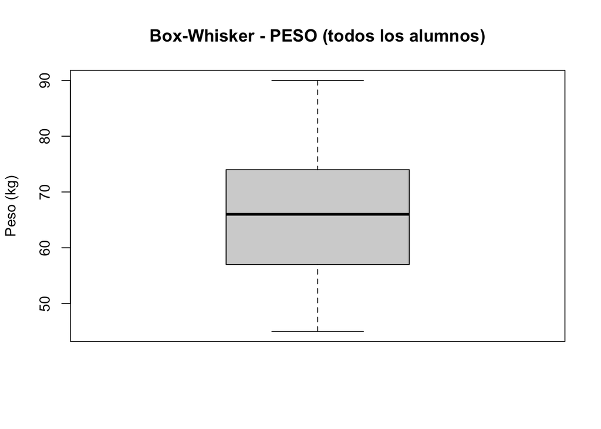

```r
boxplot(datos$PESO, main = "Box-Whisker - PESO (todos los alumnos)",
        ylab = "Peso (kg)")
```

La caja va del Q1 al Q3, la linea central es la mediana y los puntos fuera son outliers. Para describir el peso del alumnado lo mas adecuado es usar mediana (posicion) y rango intercuartilico (dispersion).